# Analysis of Health & Economic Consequences of Severe Weather Events Across the USA

Amal Haq

Wednesday, February 25, 2015

# SYNOPSIS

Weather events have a major impact on both the population and the economy. In the report below, we use data gathered by the US National Weather Service to determine the Weather Events that result in the highest population and economic impact, in death/injury tolls and US dollars respectively. The data has been heavily processed to align with the 48 weather event types recognized by the National Weather Service; additionally, the data is only reflective of weather events from the year 1993 onwards. Please note that this is largely an exploratory analysis of the available data.

# SETTING GLOBAL ENVIRONMENT

```r
library(ggplot2)
library(gridExtra)
library(data.table)
library(Rcpp)
library(plyr)
library(dplyr)
library(lubridate)
```

# DATA PROCESSING

## Data Download and Upload

```r
if(!file.exists("./project2data/stormData.csv.bz2")){dir.create("./project2data")}
fileURL<- "http://d396qusza40orc.cloudfront.net/repdata%2Fdata%2FStormData.csv.bz2"
download.file(fileURL, destfile = "./project2data/stormData.csv.bz2")


if (!"storm.data" %in% ls()) {
storm.data = read.csv(bzfile("project2data/stormData.csv.bz2"), header = TRUE)
}
```

## Data Subsetting and Cleaning

The instructions note that the earlier years represent a lack of good data. Lets evaluate the dataset to determine a good cut-off point for subsetting the data for the analysis. We can do this by calculating the different types of events per year. The data.frame shows us that our date column is actually of class ‘factor’; we need to extract the year from each date and put it in a variable column, so that we can split the dataset by year. We can use *lubridate* package functions:

```r
storm.data$year<- mdy_hms(storm.data$BGN_DATE)
storm.data$year<- year(storm.data$year)
```

Alternatively, use the base R code. The difference is merely in the class() of the storm.data$year variable.

```r
storm.data$year<-as.Date(storm.data$BGN_DATE, "%m/%d/%Y")
storm.data$year<- format(storm.data$year, "%Y")
```

If you check with 902297, 38 you will see that there are now 902297 observations for 38 variables, which means that a new column “year” has been added to the data frame. While we are at it, lets also change the factor from ‘factor’ to ‘character’.

```r
storm.data$EVTYPE<- as.character(storm.data$EVTYPE)
```

Now, lets split the data by year to calculate different events per year:

```r
no.events<- ddply(
  storm.data,
  .(year),
  summarise,
  count=length(unique(EVTYPE))
  )
```

Using *plyr* is the in vogue way of doing it, but the following uses base R code with traditional split/apply/combine

```r
no.events <- split(storm.data, storm.data$year)
no.events <- lapply(no.events, function (x) length(unique(x$EVTYPE)) )
no.events <- do.call(rbind, no.events)
```

```r
subset.storm<- storm.data[storm.data$year >=1993,]
```

This subset reduced the number of observations from 902297 to 714738.

Let’s do some heavy duty cleaning! By checking the unique values in the EVTYPE variable, we see that there are 985 different entries of EVTYPE (i.e. Event Type). According to the documentation provided in the assignment (the National Weather Service Instruction 10-1605, page 6), there should be only 48 different event types. There are a lot of inconsistencies, typos, different names for the same type of event. Therefore clean up the subset.storm$EVTYPE entries for the 714738 observations is necessary.

First, lets put all the event types in uppercase and remove unnecessary spaces. That in itself will reduce the number of unique EVTYPE:

```r
subset.storm$EVTYPE<- toupper(gsub("^\\s+|\\s+$", "", subset.storm$EVTYPE))
```

Let’s start with Thunderstorms. There are two distinct categories “THUNDERSTORM WIND” and “MARINE THUNDERSTORM WIND”. Let’s see what we have:

```r
unique(subset.storm[grep("THUNDERSTORM", subset.storm$EVTYPE),8])
```

```
##  [1] "THUNDERSTORM WINDS"             "THUNDERSTORM WIND"
##  [3] "THUNDERSTORM WINS"              "THUNDERSTORM WINDS LIGHTNING"
##  [5] "THUNDERSTORM WINDS/HAIL"        "THUNDERSTORM WINDS HAIL"
##  [7] "FLASH FLOODING/THUNDERSTORM WI" "THUNDERSTORM"
##  [9] "THUNDERSTORM WINDS/FUNNEL CLOU" "SEVERE THUNDERSTORM"
## [11] "SEVERE THUNDERSTORMS"           "SEVERE THUNDERSTORM WINDS"
## [13] "THUNDERSTORMS WINDS"            "THUNDERSTORMS"
## [15] "LIGHTNING THUNDERSTORM WINDSS"  "THUNDERSTORM WINDS 60"
## [17] "THUNDERSTORM WINDSS"            "LIGHTNING THUNDERSTORM WINDS"
## [19] "LIGHTNING AND THUNDERSTORM WIN" "THUNDERSTORM WINDS53"
## [21] "THUNDERSTORM WINDS 13"          "THUNDERSTORM WINDS URBAN FLOOD"
## [23] "THUNDERSTORM WINDS SMALL STREA" "THUNDERSTORM WINDS 2"
## [25] "THUNDERSTORM WINDS 61"          "THUNDERSTORM DAMAGE"
## [27] "THUNDERSTORMW 50"               "THUNDERSTORMS WIND"
## [29] "THUNDERSTORM  WINDS"            "THUNDERSTORM WINDS/ HAIL"
```

[output cut: 26 more lines]

```r
unique(subset.storm[grep("MARINE THUNDERSTORM", subset.storm$EVTYPE),8])
```

```
## [1] "MARINE THUNDERSTORM WIND"
```

```r
unique(subset.storm[grep("(.*)+ THUNDERSTORM", subset.storm$EVTYPE),8])
```

```
## [1] "SEVERE THUNDERSTORM"            "SEVERE THUNDERSTORMS"
## [3] "SEVERE THUNDERSTORM WINDS"      "LIGHTNING THUNDERSTORM WINDSS"
## [5] "LIGHTNING THUNDERSTORM WINDS"   "LIGHTNING AND THUNDERSTORM WIN"
## [7] "GUSTY THUNDERSTORM WINDS"       "GUSTY THUNDERSTORM WIND"
## [9] "MARINE THUNDERSTORM WIND"
```

```r
length(subset.storm[grep("THUNDERSTORM", subset.storm$EVTYPE),8])
```

```
## [1] 109572
```

```r
length(subset.storm[grep("MARINE THUNDERSTORM", subset.storm$EVTYPE),8])
```

```
## [1] 5812
```

There are 81 unique entry types for ‘Thunderstorms’, one of which is “MARINE THUNDERSTORM WIND”. And there are 9 unqiue entries that include at least one word before ‘Thunderstorm’. We want to bring down 80 unique event types to a single event type “THUNDERSTORM WIND” without affecting the “MARINE THUNDERSTORM WIND” eventype.

```r
subset.storm$EVTYPE<- gsub("MARINE THUNDERSTORM", "MARINE TSTM",subset.storm$EVTYPE)
subset.storm$EVTYPE<- gsub("(.*)+ THUNDERSTORM", "THUNDERSTORM",subset.storm$EVTYPE)
subset.storm$EVTYPE<- gsub("THUNDERSTORM(.*)", "THUNDERSTORM", subset.storm$EVTYPE)
```

But we also have entries for ‘Thunderstorms’ as “TSTM”.

```r
unique(subset.storm[grep("TSTM", subset.storm$EVTYPE),8])
```

```
##  [1] "TSTM WIND"                  "TORNADOES, TSTM WIND, HAIL"
##  [3] "TSTM WIND 51"               "TSTM WIND 50"
##  [5] "TSTM WIND 52"               "TSTM WIND 55"
##  [7] "TSTM WIND G58"              "TSTM WIND DAMAGE"
##  [9] "TSTM WINDS"                 "TSTMW"
## [11] "TSTM WIND 65)"              "TSTM WIND/HAIL"
## [13] "TSTM WIND (G45)"            "TSTM HEAVY RAIN"
## [15] "TSTM WIND 40"               "TSTM WIND 45"
## [17] "TSTM WIND (41)"             "TSTM WIND (G40)"
## [19] "TSTM WND"                   "TSTM WIND AND LIGHTNING"
## [21] "TSTM WIND  (G45)"           "TSTM WIND (G35)"
## [23] "TSTM"                       "TSTM WIND G45"
## [25] "NON-TSTM WIND"              "NON TSTM WIND"
## [27] "MARINE TSTM WIND"
```

The code below takes care of any entries that begin with *TSTM WIND* to include ‘TSTM WIND/TSTM WIND*S*/TSTM WIND*/HAIL*/TSTM WIND *(insert any other word or words*)’

```r
subset.storm$EVTYPE<- gsub("^TSTM WIND(.*)|^TSTM WIND (.*)", "THUNDERSTORM", subset.storm$EVTYPE)
```

Then, the code below takes care of any remaining entries. Specifically, any entries that begin with *TSTM*, * TSTM* (space before TSTM), and the specific entries *TSTM* and *TSTMW*.

```r
subset.storm$EVTYPE<- gsub("^TSTM (.*)|^\\s+TSTM (.*)|^TSTM$|TSTMW", "THUNDERSTORM", subset.storm$EVTYPE)
subset.storm$EVTYPE<- gsub("^THU.*|^TUN.*", "THUNDERSTORM", subset.storm$EVTYPE)
```

We have shaved off over 100 unique entries (from 985 to 881) by recategorizing them as regular or marine thunderstorms. To be concise and to maintain clarity, we have change the “THUNDERSTORM WIND” and “MARINE THUNDERSTORM WIND” categories to “THUNDERSTORM” and “MARINE TSTM” respectively. **SIMILARLY**, we need to continue our data clean-up process to boil down our unique entries in storm.data$EVTYPE and bring it as close as possible to the 48 categories recognized by the National Weather Service. At the very least, we have to at least clean up the data so the 48 event types are reflected properly for our later computations.

Because we don’t have a Subject Matter Expert at hand, we will need to make some educated guesses about categories (e.g., a ‘BEACH FLOOD’ entry can be recategorized as ‘COASTAL FLOOD’). Additionally, anywhere the entry indicates multiple event types (e.g., ‘SLEET/SNOW’), we will categorize by the first entry for simplicity. Therefore, SLEET/SNOW is categorized as ‘SLEET’, and SNOW/SLEET is categorized as ‘SNOW’.

Below, with the help of the unique() function to make decisions about appropriate substitutions, and the gsub() function, we can clean up the remainder of the EVTYPE variable.

```r
subset.storm$EVTYPE<- gsub("^BLIZZARD(.*)|GROUND BLIZZARD", "BLIZZARD", subset.storm$EVTYPE)
unique(subset.storm[grep("COASTAL", subset.storm$EVTYPE),8])
```

```
##  [1] "COASTAL FLOOD"               "HEAVY SURF COASTAL FLOODING"
##  [3] "COASTAL FLOODING"            "COASTAL SURGE"
##  [5] "HIGH WINDS/COASTAL FLOOD"    "COASTAL/TIDAL FLOOD"
##  [7] "BEACH EROSION/COASTAL FLOOD" "COASTAL STORM"
##  [9] "COASTALFLOOD"                "COASTALSTORM"
## [11] "COASTAL FLOODING/EROSION"    "COASTAL EROSION"
## [13] "COASTAL  FLOODING/EROSION"
```

```r
subset.storm$EVTYPE<- gsub("(.*)COASTAL(.*)", "COASTAL FLOOD", subset.storm$EVTYPE)
subset.storm$EVTYPE<- gsub("TIDAL(.*)|BEACH(.*)|CSTL(.*)", "COASTAL FLOOD", subset.storm$EVTYPE)
subset.storm$EVTYPE<- gsub("LAKE(.*) FLOOD", "LAKESHORE FLOOD", subset.storm$EVTYPE)
subset.storm$EVTYPE<- gsub("^FLASH FLOOD(.*)", "FLASH FLOOD", subset.storm$EVTYPE)
subset.storm$EVTYPE<- gsub("FLASH FLOOODING|^ +FLASH FLOOD|LOCAL FLASH FLOOD", "FLASH FLOOD", subset.storm$EVTYPE)
subset.storm$EVTYPE<- gsub("^FLOOD(.*)|LOCAL FLOOD|BREAKUP FLOODING", "FLOOD", subset.storm$EVTYPE)
subset.storm$EVTYPE<- gsub("^URBAN(.*) FLOOD(.*)|^R(.*) FLOOD(.*)|^S(.*) FLOOD(.*)|^M(.*) FLOOD(.*)|^H(.*) FLOOD(.*)", "FLOOD", subset.storm$EVTYPE)
unique(subset.storm[grep("COLD", subset.storm$EVTYPE),8])
```

```
##  [1] "RECORD COLD"                  "COLD"
##  [3] "EXTREME COLD"                 "RECORD COLD AND HIGH WIND"
##  [5] "UNSEASONABLY COLD"            "EXTREME/RECORD COLD"
##  [7] "SEVERE COLD"                  "COLD WAVE"
##  [9] "COLD AND WET CONDITIONS"      "COLD AIR FUNNEL"
## [11] "COLD AIR FUNNELS"             "COLD AIR TORNADO"
## [13] "PROLONG COLD"                 "FOG AND COLD TEMPERATURES"
## [15] "SNOW/COLD"                    "RECORD COLD/FROST"
## [17] "RECORD SNOW/COLD"             "HIGH WINDS/COLD"
## [19] "COLD/WINDS"                   "SNOW/ BITTER COLD"
## [21] "COLD WEATHER"                 "SNOW AND COLD"
## [23] "PROLONG COLD/SNOW"            "SNOW\\COLD"
## [25] "UNSEASONABLE COLD"            "EXCESSIVE COLD"
## [27] "EXTENDED COLD"                "COLD TEMPERATURE"
## [29] "COLD AND SNOW"                "COLD AND FROST"
## [31] "COLD TEMPERATURES"            "COLD WIND CHILL TEMPERATURES"
## [33] "RECORD  COLD"                 "UNUSUALLY COLD"
## [35] "EXTREME COLD/WIND CHILL"      "COLD/WIND CHILL"
```

```r
subset.storm$EVTYPE<- gsub("EXTREME.*COLD.*|RECORD +COLD|SEVERE COLD", "EXTREME WIND CHILL", subset.storm$EVTYPE)
unique(subset.storm[grep("FOG", subset.storm$EVTYPE),8])
```

```
## [1] "DENSE FOG"                 "FOG"
## [3] "FOG AND COLD TEMPERATURES" "ICE FOG"
## [5] "FREEZING FOG"              "PATCHY DENSE FOG"
```

```r
subset.storm$EVTYPE<- gsub("FREEZING FOG", "FF", subset.storm$EVTYPE)
subset.storm$EVTYPE<- gsub(".*FOG.*", "FOG", subset.storm$EVTYPE)
subset.storm$EVTYPE<- gsub("^FF$", "FREEZING FOG", subset.storm$EVTYPE)
subset.storm$EVTYPE<- gsub("^WIND CHILL.*", "COLD/WIND CHILL", subset.storm$EVTYPE)
subset.storm$EVTYPE<- gsub("^COLD.*|.*[^/\\]COLD.*", "COLD/WIND CHILL", subset.storm$EVTYPE)
subset.storm$EVTYPE<- gsub(".*SMOKE.*", "DENSE SMOKE", subset.storm$EVTYPE)
subset.storm$EVTYPE<- gsub(".*[^/]DROUGHT|^DROUGHT.*", "DROUGHT", subset.storm$EVTYPE)
subset.storm$EVTYPE<- gsub("^DUST D(.*)", "DUST DEVIL", subset.storm$EVTYPE)
subset.storm$EVTYPE<- gsub("DUSTSTORM|.* DUST +.*|DUST STORM/.*|.*DUST$", "DUST STORM", subset.storm$EVTYPE)
subset.storm$EVTYPE<- gsub("^BITTER|^LOW TEMPERATURE|.*LOW TEMP|RECORD LOW$", "EXTREME COLD/WIND CHILL", subset.storm$EVTYPE)
subset.storm$EVTYPE<- gsub("EXTREME.*WIND.*CHILL.*", "EXTREME COLD/WIND CHILL", subset.storm$EVTYPE)
subset.storm$EVTYPE<- gsub(".*FROST.*", "FROST/FREEZE", subset.storm$EVTYPE)
subset.storm$EVTYPE<- gsub(".*FUNNEL.*|.*WALL CLOUD.*", "FUNNEL CLOUD", subset.storm$EVTYPE)
subset.storm$EVTYPE<- gsub("MARINE HAIL", "MARINE-H", subset.storm$EVTYPE)
subset.storm$EVTYPE<- gsub("^HAIL.*|.*[^/]HAIL.*", "HAIL", subset.storm$EVTYPE)
subset.storm$EVTYPE<- gsub("MARINE-H", "MARINE HAIL", subset.storm$EVTYPE)
subset.storm$EVTYPE<- gsub("^HEAT.*", "HEAT", subset.storm$EVTYPE)
subset.storm$EVTYPE<- gsub("^EXCESSIVE.*HEAT.*|^RECORD.*HEAT|^EXTREME.*HEAT", "EXCESSIVE HEAT", subset.storm$EVTYPE)
subset.storm$EVTYPE<- gsub("^RECORD.*TEMP.*|^HIGH.*TEMP", "EXCESSIVE HEAT", subset.storm$EVTYPE)
subset.storm$EVTYPE<- gsub("^RAIN.*|^HEAVY RAIN.*|LOCALLY HEAVY RAIN", "HEAVY RAIN", subset.storm$EVTYPE)
subset.storm$EVTYPE<- gsub("^RECORD.*RAIN.*|^EXCESSIVE.*RAIN.*|^HVY.*|^TORRENTIAL.*|^PROLONGED.*|^HEAVY PRECIP.*|^HEAVY SHOWER.*", "HEAVY RAIN", subset.storm$EVTYPE)
subset.storm$EVTYPE<- gsub("^SNOW.*|^HEAVY SNOW.*", "HEAVY SNOW", subset.storm$EVTYPE)
subset.storm$EVTYPE<- gsub(".*RECORD.*SNOW.*|^EXCESSIVE.*SNOW.*|^BLOWING.*|THUNDERSNOW|.*WET SNOW", "HEAVY SNOW", subset.storm$EVTYPE)
subset.storm$EVTYPE<- gsub("RIP.*", "RIP CURRENT", subset.storm$EVTYPE)
subset.storm$EVTYPE<- gsub(".*SURF.*", "HIGH SURF", subset.storm$EVTYPE)
subset.storm$EVTYPE<- gsub("^HIGH.*WIND.*", "HIGH WIND", subset.storm$EVTYPE)
subset.storm$EVTYPE<- gsub("^HURRICANE.*", "HURRICANE(TYPHOON)", subset.storm$EVTYPE)
subset.storm$EVTYPE<- gsub("^SLEET.*|^FREEZING RAIN|FREEZING DRIZZLE.*", "SLEET", subset.storm$EVTYPE)
subset.storm$EVTYPE<- gsub(".*ICE.*", "ICE STORM", subset.storm$EVTYPE)
subset.storm$EVTYPE<- gsub(".*LAKE.*SNOW", "LAKE-EFFECT SNOW", subset.storm$EVTYPE)
subset.storm$EVTYPE<- gsub(".*LIGHTNING.*", "LIGHTNING", subset.storm$EVTYPE)
subset.storm$EVTYPE<- gsub("^STORM SURGE.*", "STORM SURGE/TIDE", subset.storm$EVTYPE)
subset.storm$EVTYPE<- gsub("STRONG WIND.*|^GUSTY.*|.*BURST.*", "STRONG WIND", subset.storm$EVTYPE)
subset.storm$EVTYPE<- gsub("^TORNADO.*", "TORNADO", subset.storm$EVTYPE)
subset.storm$EVTYPE<- gsub("^TROPICAL STORM.*", "TROPICAL STORM", subset.storm$EVTYPE)
subset.storm$EVTYPE<- gsub("^TORNADO.*", "TORNADO", subset.storm$EVTYPE)
subset.storm$EVTYPE<- gsub("^VOLCANIC.*", "VOLCANIC ASH", subset.storm$EVTYPE)
subset.storm$EVTYPE<- gsub(".*WATERSPOUT.*|^WA.*SPOUT", "WATERSPOUT", subset.storm$EVTYPE)
subset.storm$EVTYPE<- gsub("^WILD.*FIRE.*", "WILDFIRE", subset.storm$EVTYPE)
subset.storm$EVTYPE<- gsub("^WINTER STORM.*", "WINTER STORM", subset.storm$EVTYPE)
subset.storm$EVTYPE<- gsub("^WINTER WEATHER.*", "WINTER WEATHER", subset.storm$EVTYPE)
```

We have significantly reduced the number of unique event types (from 985 to 309). This is not the best that it could but we will be able to further reduce our dataset size by cleaningthe ‘PROPDMGEXP’ ‘CROPDMGEXP’ variables, and then subsetting by the ‘PROPDMG’ ‘CROPDMG’ variables.

```r
unique(subset.storm$PROPDMGEXP)
```

```
##  [1]   B K M m + 0 5 6 ? 4 2 3 h 7 H - 1 8
## Levels:  - ? + 0 1 2 3 4 5 6 7 8 B h H K m M
```

```r
unique(subset.storm$CROPDMGEXP)
```

```
## [1]   M K m B ? 0 k 2
## Levels:  ? 0 2 B k K m M
```

The PROPDMEXP/CROPDMGEXP should provide the ‘exponent’ or power to which the PROPDMG/CROPDMG valriables have to be raised. The letters H,K,M,B, represent the exponents 2,3,6,9 or the exponential values 10^2, 10^3, 10^6, 10^9 respectively. However, the PROPDMGEXP and CROPDMGEXP columns have both alphabetic and numeric entries, as well as some random symbols. This mean, for example, anywhere there is a ‘5’ in PROPDMEXP/CROPDMGEXP, the PROPDMG/CROPDMG values have to be multiplied by 10^5 to give the total value of the damage. Whereas, anywhere there is a ‘K’ in PROPDMEXP/CROPDMGEXP, the PROPDMG/CROPDMG values have to be multiplied by 10^3. Therefore, we first have to standardize the entry format. We can use the gsub() function again and write a loop to make the necessary replacements.

```r
subset.storm$PROPDMGEXP<- gsub("\\+|-|\\?", "0", subset.storm$PROPDMGEXP)
subset.storm$CROPDMGEXP<- gsub("\\?", "0", subset.storm$CROPDMGEXP)
subset.storm$PROPDMGEXP<- toupper(subset.storm$PROPDMGEXP)
subset.storm$CROPDMGEXP<- toupper(subset.storm$CROPDMGEXP)

exponent <- function(X) {
        if (X == "H") {
                    X<-2
                    }
            else if (X == "K"){
                    X<-3
                    }
            else if (X == "M"){
                    X<-6
                    }
            else if (X == "B"){
                    X<-9
                    }
            else if (X == ""){
                    X<-0
                    }
        else{
                X<-X
                }
        }
```

As you can see from the code above, unless the entry is a letter or a number, I have set the exponent to be 0. Exponent set to 0 means that the property or crop damage is being raised to 10^0, and 10^0 =1. In these cases, the multiplier is 1, or in other words: *Total Property Damage = PROPDMG x 10^PROPDMXEXP = PROPDMG x 1 = PROPDMG*

Then we simply apply the function to the variables:

```r
subset.storm$PROPDMGEXP<- as.numeric(sapply(subset.storm$PROPDMGEXP, exponent))
subset.storm$CROPDMGEXP<- as.numeric(sapply(subset.storm$CROPDMGEXP, exponent))
```

Now, we can create new variables that reflect the total property damage and crop damage values.

```r
subset.storm<- mutate(subset.storm, TOTALPROPDMG = subset.storm$PROPDMG * 10^subset.storm$PROPDMGEXP)
subset.storm<- mutate(subset.storm, TOTALCROPDMG = subset.storm$CROPDMG * 10^subset.storm$CROPDMGEXP)
```

In our analysis in the following section, we are interested in events that are either harmful or cause economic damage, we can do an additional subset to reduce our dataset to exclude event types that do not cause injuries, fatalities, property damage or crop damage:

```r
subset.storm<- subset(subset.storm, INJURIES > 0 | FATALITIES > 0 | TOTALPROPDMG > 0 | TOTALCROPDMG > 0)
```

# RESULTS

## QUESTION 1: Across the United States, which types of events (as indicated in the EVTYPE variable) are most harmful with respect to population health?

Let’s process the cleaned and subsetted data we produced in the section above a little more. We calculate the *total fatalities*, *total injuries* as well as the *total population* affected (fatalities plus injuries), for each event type. We can do this easily by grouping the data along the EVTYPE variable and creating new data frames with variables that reflect the totals.

```r
popl.impact<- ddply(
  subset.storm,
  c("EVTYPE"),
  summarise,
  TOTAL.FATALITIES=sum(FATALITIES),
  TOTAL.INJURIES=sum(INJURIES),
  TOTAL.POP.DMG=sum(FATALITIES+INJURIES)
  )

popl.deaths<- popl.impact[order(-popl.impact$TOTAL.FATALITIES),]
popl.deaths<- popl.deaths[1:10, 1:2]

popl.injuries<- popl.impact[order(-popl.impact$TOTAL.INJURIES),]
popl.injuries<- popl.injuries[1:10, c("EVTYPE", "TOTAL.INJURIES")]

popl.overall<- popl.impact[order(-popl.impact$TOTAL.POP.DMG),]
popl.overall<- popl.overall[1:10, c("EVTYPE", "TOTAL.POP.DMG")]
```

Now, plot:

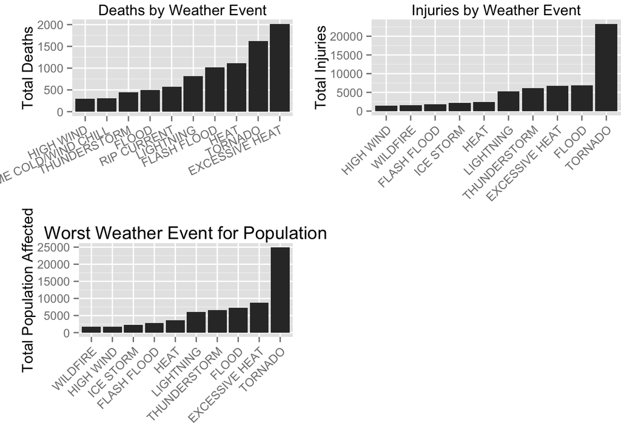

```r
g1<- ggplot(popl.deaths, aes(x= reorder(EVTYPE, TOTAL.FATALITIES), y=TOTAL.FATALITIES)) +
        geom_bar(stat = "identity") +
        ggtitle("Deaths by Weather Event") +
        xlab("") +
        ylab("Total Deaths") +
        theme(axis.text.x=element_text(angle = 25, hjust = 1), plot.margin = unit(c(0,1,0,1), "lines"), plot.title=element_text(size=12))

g2<- ggplot(popl.injuries, aes(x= reorder(EVTYPE, TOTAL.INJURIES), y=TOTAL.INJURIES)) +
        geom_bar(stat = "identity") +
        ggtitle("Injuries by Weather Event") +
        xlab("") +
        ylab("Total Injuries") +
        theme(axis.text.x=element_text(angle = 45, hjust = 1), plot.margin = unit(c(0,0,0,0), "lines"), plot.title=element_text(size=12))

g3<- ggplot(popl.overall, aes(x= reorder(EVTYPE, TOTAL.POP.DMG), y=TOTAL.POP.DMG)) +
        geom_bar(stat = "identity") +
        ggtitle("Worst Weather Event for Population") +
        xlab("") +
        ylab("Total Population Affected") +
        theme(axis.text.x=element_text(angle = 45, hjust = 1), plot.margin = unit(c(0,1,0,1), "lines"))

grid.arrange(g1,g2,g3, nrow=2, ncol=2)
```

**The oveall most harmful event with respect to population health is a TORNADO; however, the weather event that causes most deaths is EXCESSIVE HEAT. TORNADOES are a close second for population deaths, however, they are the primary weather event that for the highest number of injuries.**

## QUESTION 2: Across the United States, which types of events have the greatest economic consequences?

We can process the cleaned and subsetted data we prodcued in the previous section for economic impact in exactly the same way we did for population impact:

```r
econ.impact<- ddply(
  subset.storm,
  c("EVTYPE"),
  summarise,
  TOTALPROPDMG=sum(TOTALPROPDMG),
  TOTALCROPDMG=sum(TOTALCROPDMG),
  TOTALDMG=sum(TOTALPROPDMG+TOTALCROPDMG)
  )

econdmgprop<- econ.impact[order(-econ.impact$TOTALPROPDMG),]
econdmgprop<- econdmgprop[1:10, 1:2]

econdmgcrop<- econ.impact[order(-econ.impact$TOTALCROPDMG),]
econdmgcrop<- econdmgcrop[1:10, c("EVTYPE", "TOTALCROPDMG")]

econ.overall<- econ.impact[order(-econ.impact$TOTALDMG),]
econ.overall<- econ.overall[1:10, c("EVTYPE", "TOTALDMG")]
```

And, we can plot with a nearly identical code, making sure to use the correct arguments and labels:

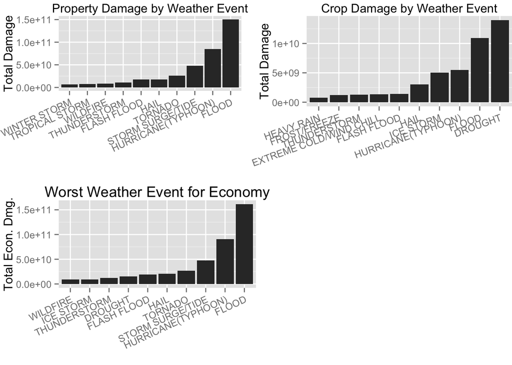

```r
g4<- ggplot(econdmgprop, aes(x= reorder(EVTYPE, TOTALPROPDMG), y=TOTALPROPDMG)) +
        geom_bar(stat = "identity") +
        ggtitle("Property Damage by Weather Event") +
        xlab("") +
        ylab("Total Damage") +
        theme(axis.text.x=element_text(angle = 25, hjust = 1), plot.margin = unit(c(0,1,1,0), "lines"), plot.title=element_text(size=12))

g5<- ggplot(econdmgcrop, aes(x= reorder(EVTYPE, TOTALCROPDMG), y=TOTALCROPDMG)) +
        geom_bar(stat = "identity") +
        ggtitle("Crop Damage by Weather Event") +
        xlab("") +
        ylab("Total Damage") +
        theme(axis.text.x=element_text(angle = 20, hjust = 1), plot.margin = unit(c(0,0,0,0), "lines"), plot.title=element_text(size=12))

g6<- ggplot(econ.overall, aes(x= reorder(EVTYPE, TOTALDMG), y=TOTALDMG)) +
        geom_bar(stat = "identity") +
        ggtitle("Worst Weather Event for Economy") +
        xlab("") +
        ylab("Total Econ. Dmg.") +
        theme(axis.text.x=element_text(angle = 25, hjust = 1), plot.margin = unit(c(0,0,0,0), "lines"))

grid.arrange(g4,g5,g6, nrow=2, ncol=2)
```